# Emergency Department Patients Data Analysis Project

## Questions:

Q1:Which 5 hospitals have the highest total number of admissions?

Q2:Are there any noticeable patterns or fluctuations in admissions throughout the year?

Q3:Do certain seasons correlate with an increase or decrease in patient admissions?

```python
#importing liabraries
import pandas as pd
import numpy as np
import matplotlib.pyplot as plt
import seaborn as sns
# suppress warnings from final output
import warnings
warnings.simplefilter("ignore")
```

```python
#Load_dataset
df=pd.read_csv('Emergency_data.csv')
```

```python
df
```

|  | hospital_name | December | November | October | September | August | July | June | May | April | March | February | January | total | Unnamed: 14 |
| --- | --- | --- | --- | --- | --- | --- | --- | --- | --- | --- | --- | --- | --- | --- | --- |
| 0 | Prince Sultan Military Medical City, Riyadh | 11811.0 | 12528.0 | 14135.0 | 12079.0 | 11118.0 | 10634.0 | 13160.0 | 13309.0 | 11300.0 | 11472.0 | 10466.0 | 12382.0 | 144394.0 | NaN |
| 1 | NaN | 11811.0 | 12528.0 | 14135.0 | 12079.0 | 11118.0 | 10634.0 | 13160.0 | 13309.0 | 11300.0 | 11472.0 | 10466.0 | 12382.0 | 144394.0 | NaN |
| 2 | Prince Sultan Center for Cardiac Diseases and ... | 0.0 | 0.0 | 0.0 | 0.0 | 0.0 | 0.0 | 0.0 | 0.0 | 0.0 | 0.0 | 0.0 | 0.0 | 0.0 | NaN |
| 3 | NaN | 0.0 | 0.0 | 0.0 | 0.0 | 0.0 | 0.0 | 0.0 | 0.0 | 0.0 | 0.0 | 0.0 | 0.0 | 0.0 | NaN |
| 4 | Hospital of the General Organization for Milit... | 7580.0 | 8292.0 | 10962.0 | 8031.0 | 6740.0 | 6464.0 | 8247.0 | 8550.0 | 8039.0 | 6709.0 | 7285.0 | 7513.0 | 94412.0 | NaN |
| 5 | NaN | 7580.0 | 8292.0 | 10962.0 | 8031.0 | 6740.0 | 6464.0 | 8247.0 | 8550.0 | 8039.0 | 6709.0 | 7285.0 | 7513.0 | 94412.0 | NaN |
| 6 | Armed Forces Hospital in Al-Kharj | 1323.0 | 2075.0 | 2553.0 | 1429.0 | 813.0 | 835.0 | 1788.0 | 1490.0 | 1502.0 | 1245.0 | 1233.0 | 1528.0 | 17814.0 | NaN |
| 7 | NaN | 1323.0 | 2075.0 | 2553.0 | 1429.0 | 813.0 | 835.0 | 1788.0 | 1490.0 | 1502.0 | 1245.0 | 1233.0 | 1528.0 | 17814.0 | NaN |
| 8 | King Fahd Armed Forces Hospital in Jeddah | 11975.0 | 11707.0 | 13318.0 | 11525.0 | 11211.0 | 10297.0 | 11716.0 | 12663.0 | 11127.0 | 11387.0 | 9625.0 | 10709.0 | 137260.0 | NaN |
| 9 | NaN | 11975.0 | 11707.0 | 13318.0 | 11525.0 | 11211.0 | 10297.0 | 11716.0 | 12663.0 | 11127.0 | 11387.0 | 9625.0 | 10709.0 | 137260.0 | NaN |
| 10 | Al Hada Armed Forces Hospital | 9152.0 | 9032.0 | 10955.0 | 10360.0 | 10113.0 | 8900.0 | 12541.0 | 12765.0 | 9684.0 | 11274.0 | 12803.0 | 13346.0 | 130925.0 | NaN |
| 11 | NaN | 9152.0 | 9032.0 | 10955.0 | 10360.0 | 10113.0 | 8900.0 | 12541.0 | 12765.0 | 9684.0 | 11274.0 | 12803.0 | 13346.0 | 130925.0 | NaN |
| 12 | Prince Mansour Military Hospital in Taif | 5046.0 | 4530.0 | 6809.0 | 4601.0 | 3911.0 | 5016.0 | 7462.0 | 6642.0 | 3075.0 | 1957.0 | 4112.0 | 8798.0 | 61959.0 | NaN |
| 13 | NaN | 5046.0 | 4530.0 | 6809.0 | 4601.0 | 3911.0 | 5016.0 | 7462.0 | 6642.0 | 3075.0 | 1957.0 | 4112.0 | 8798.0 | 61959.0 | NaN |
| 14 | Prince Sultan Hospital, King Fahd Air Base, Taif | 9482.0 | 10013.0 | 11741.0 | 10036.0 | 8691.0 | 8696.0 | 9046.0 | 11425.0 | 9565.0 | 8474.0 | 7151.0 | 8991.0 | 113311.0 | NaN |
| 15 | NaN | 9482.0 | 10013.0 | 11741.0 | 10036.0 | 8691.0 | 8696.0 | 9046.0 | 11425.0 | 9565.0 | 8474.0 | 7151.0 | 8991.0 | 113311.0 | NaN |
| 16 | Armed Forces Center for Health Rehabilitation ... | 0.0 | 0.0 | 0.0 | 0.0 | 0.0 | 0.0 | 0.0 | 0.0 | 0.0 | 0.0 | 0.0 | 0.0 | 0.0 | NaN |
| 17 | NaN | 0.0 | 0.0 | 0.0 | 0.0 | 0.0 | 0.0 | 0.0 | 0.0 | 0.0 | 0.0 | 0.0 | 0.0 | 0.0 | NaN |
| 18 | Armed Forces Center for Health Rehabilitation ... | 0.0 | 0.0 | 0.0 | 0.0 | 0.0 | 0.0 | 0.0 | 0.0 | 0.0 | 0.0 | 0.0 | 0.0 | 0.0 | NaN |
| 19 | NaN | 0.0 | 0.0 | 0.0 | 0.0 | 0.0 | 0.0 | 0.0 | 0.0 | 0.0 | 0.0 | 0.0 | 0.0 | 0.0 | NaN |
| 20 | Armed Forces Center for Psychological Care | 0.0 | 0.0 | 0.0 | 0.0 | 0.0 | 0.0 | 0.0 | 0.0 | 0.0 | 0.0 | 0.0 | 0.0 | 0.0 | NaN |
| 21 | NaN | 0.0 | 0.0 | 0.0 | 0.0 | 0.0 | 0.0 | 0.0 | 0.0 | 0.0 | 0.0 | 0.0 | 0.0 | 0.0 | NaN |
| 22 | King Fahd Military Medical Complex in Dhahran | 34163.0 | 34443.0 | 40752.0 | 25845.0 | 29878.0 | 22621.0 | 45355.0 | 34131.0 | 21929.0 | 44771.0 | 56896.0 | 45197.0 | 435981.0 | NaN |
| 23 | King Abdulaziz Air Base Hospital, Dhahran | 5222.0 | 5476.0 | 5308.0 | 4787.0 | 3643.0 | 3345.0 | 5839.0 | 5570.0 | 3852.0 | 3629.0 | 3542.0 | 4269.0 | 54482.0 | NaN |
| 24 | NaN | 5222.0 | 5476.0 | 5308.0 | 4787.0 | 3643.0 | 3345.0 | 5839.0 | 5570.0 | 3852.0 | 3629.0 | 3542.0 | 4269.0 | 54482.0 | NaN |
| 25 | King Abdulaziz Naval Base Hospital in Jubail | 5712.0 | 6530.0 | 7857.0 | 6444.0 | 3740.0 | 2988.0 | 6328.0 | 4549.0 | 3374.0 | 2859.0 | 3851.0 | 5136.0 | 59368.0 | NaN |
| 26 | NaN | 5712.0 | 6530.0 | 7857.0 | 6444.0 | 3740.0 | 2988.0 | 6328.0 | 4549.0 | 3374.0 | 2859.0 | 3851.0 | 5136.0 | 59368.0 | NaN |
| 27 | Armed Forces Hospital In South Region | 10026.0 | 11885.0 | 14634.0 | 14444.0 | 12117.0 | 10828.0 | 13725.0 | 15446.0 | 11547.0 | 8964.0 | 8280.0 | 8586.0 | 140482.0 | NaN |
| 28 | NaN | 10026.0 | 11885.0 | 14634.0 | 14444.0 | 12117.0 | 10828.0 | 13725.0 | 15446.0 | 11547.0 | 8964.0 | 8280.0 | 8586.0 | 140482.0 | NaN |
| 29 | Armed Forces Hospital In Sharora | 4717.0 | 4634.0 | 5113.0 | 4299.0 | 2978.0 | 2711.0 | 4625.0 | 5357.0 | 5080.0 | 3508.0 | 3210.0 | 3907.0 | 50139.0 | NaN |
| 30 | NaN | 4717.0 | 4634.0 | 5113.0 | 4299.0 | 2978.0 | 2711.0 | 4625.0 | 5357.0 | 5080.0 | 3508.0 | 3210.0 | 3907.0 | 50139.0 | NaN |
| 31 | Armed Forces Hospital In Najran | 2393.0 | 2820.0 | 3548.0 | 2907.0 | 2174.0 | 1968.0 | 4168.0 | 2369.0 | 2369.0 | 1674.0 | 1745.0 | 1843.0 | 29978.0 | NaN |
| 32 | NaN | 2393.0 | 2820.0 | 3548.0 | 2907.0 | 2174.0 | 1968.0 | 4168.0 | 2369.0 | 2369.0 | 1674.0 | 1745.0 | 1843.0 | 29978.0 | NaN |
| 33 | Armed Forces Hospital In Jazan | 2911.0 | 2997.0 | 3354.0 | 3051.0 | 2632.0 | 2486.0 | 1488.0 | 2599.0 | 1292.0 | 821.0 | 27.0 | 51.0 | 23709.0 | NaN |
| 34 | NaN | 2911.0 | 2997.0 | 3354.0 | 3051.0 | 2632.0 | 2486.0 | 1488.0 | 2599.0 | 1292.0 | 821.0 | 27.0 | 51.0 | 23709.0 | NaN |
| 35 | King Salman Armed Forces In The North West Region | 15657.0 | 16303.0 | 18446.0 | 15191.0 | 12719.0 | 11310.0 | 15782.0 | 18133.0 | 14555.0 | 12970.0 | 14355.0 | 16840.0 | 182261.0 | NaN |
| 36 | NaN | 15657.0 | 16303.0 | 18446.0 | 15191.0 | 12719.0 | 11310.0 | 15782.0 | 18133.0 | 14555.0 | 12970.0 | 14355.0 | 16840.0 | 182261.0 | NaN |
| 37 | Northen Military Hospital | 2596.0 | 2520.0 | 3254.0 | 2478.0 | 1950.0 | 1530.0 | 3061.0 | 2975.0 | 2811.0 | 2564.0 | 2514.0 | 2608.0 | 30861.0 | NaN |
| 38 | NaN | 2596.0 | 2520.0 | 3254.0 | 2478.0 | 1950.0 | 1530.0 | 3061.0 | 2975.0 | 2811.0 | 2564.0 | 2514.0 | 2608.0 | 30861.0 | NaN |
| 39 | Prince Sultan Armed Forces Hospital In Medina | 3706.0 | 3570.0 | 4326.0 | 3784.0 | 3640.0 | 3730.0 | 3844.0 | 4794.0 | 3564.0 | 3230.0 | 2699.0 | 3391.0 | 44278.0 | NaN |
| 40 | NaN | 3706.0 | 3570.0 | 4326.0 | 3784.0 | 3640.0 | 3730.0 | 3844.0 | 4794.0 | 3564.0 | 3230.0 | 2699.0 | 3391.0 | 44278.0 | NaN |
| 41 | NaN | NaN | NaN | NaN | NaN | NaN | NaN | NaN | NaN | NaN | NaN | NaN | NaN | NaN | NaN |
| 42 | NaN | NaN | NaN | NaN | NaN | NaN | NaN | NaN | NaN | NaN | NaN | NaN | NaN | NaN | NaN |
| 43 | Wadi Adwaser Armed Forces Hospital | 2071.0 | 2116.0 | 2418.0 | 1936.0 | 1667.0 | 1767.0 | 2455.0 | 2482.0 | 2015.0 | 1418.0 | 1323.0 | 1298.0 | 22966.0 | NaN |
| 44 | NaN | 2071.0 | 2116.0 | 2418.0 | 1936.0 | 1667.0 | 1767.0 | 2455.0 | 2482.0 | 2015.0 | 1418.0 | 1323.0 | 1298.0 | 22966.0 | NaN |
| 45 | Qassim Armed Forces Hospital | 1104.0 | 1503.0 | 1933.0 | 1146.0 | 750.0 | 959.0 | 1377.0 | 1389.0 | 1193.0 | 1081.0 | 1382.0 | 1595.0 | 15412.0 | NaN |
| 46 | NaN | 1104.0 | 1503.0 | 1933.0 | 1146.0 | 750.0 | 959.0 | 1377.0 | 1389.0 | 1193.0 | 1081.0 | 1382.0 | 1595.0 | 15412.0 | NaN |
| 47 | NaN | NaN | NaN | NaN | NaN | NaN | NaN | NaN | NaN | NaN | NaN | NaN | NaN | NaN | NaN |
| 48 | NaN | NaN | NaN | NaN | NaN | NaN | NaN | NaN | NaN | NaN | NaN | NaN | NaN | NaN | Data of emergency department patients in the h... |

```python
#Structure of the Data
df.shape
```

```
(49, 15)
```

```python
df.dtypes
```

```
hospital_name     object
December         float64
November         float64
October          float64
September        float64
August           float64
July             float64
June             float64
May              float64
April            float64
March            float64
February         float64
January          float64
total            float64
Unnamed: 14       object
dtype: object
```

```python
#Droping_columns
df.drop(['Unnamed: 14'],axis=1,inplace=True)
```

```python
#Dropping null values
df.isnull().sum()
```

```
hospital_name    26
December          4
November          4
October           4
September         4
August            4
July              4
June              4
May               4
April             4
March             4
February          4
January           4
total             4
dtype: int64
```

```python
df.dropna(inplace=True)
```

```python
df.isnull().sum()
```

```
hospital_name    0
December         0
November         0
October          0
September        0
August           0
July             0
June             0
May              0
April            0
March            0
February         0
January          0
total            0
dtype: int64
```

```python
#handlng duplicated data
df.duplicated()
```

```
0     False
2     False
4     False
6     False
8     False
10    False
12    False
14    False
16    False
18     True
20    False
22    False
23    False
25    False
27    False
29    False
31    False
33    False
35    False
37    False
39    False
43    False
45    False
dtype: bool
```

```python
#Delete all NaN
df = df.dropna()
```

```python
df
```

|  | hospital_name | December | November | October | September | August | July | June | May | April | March | February | January | total |
| --- | --- | --- | --- | --- | --- | --- | --- | --- | --- | --- | --- | --- | --- | --- |
| 0 | Prince Sultan Military Medical City, Riyadh | 11811.0 | 12528.0 | 14135.0 | 12079.0 | 11118.0 | 10634.0 | 13160.0 | 13309.0 | 11300.0 | 11472.0 | 10466.0 | 12382.0 | 144394.0 |
| 2 | Prince Sultan Center for Cardiac Diseases and ... | 0.0 | 0.0 | 0.0 | 0.0 | 0.0 | 0.0 | 0.0 | 0.0 | 0.0 | 0.0 | 0.0 | 0.0 | 0.0 |
| 4 | Hospital of the General Organization for Milit... | 7580.0 | 8292.0 | 10962.0 | 8031.0 | 6740.0 | 6464.0 | 8247.0 | 8550.0 | 8039.0 | 6709.0 | 7285.0 | 7513.0 | 94412.0 |
| 6 | Armed Forces Hospital in Al-Kharj | 1323.0 | 2075.0 | 2553.0 | 1429.0 | 813.0 | 835.0 | 1788.0 | 1490.0 | 1502.0 | 1245.0 | 1233.0 | 1528.0 | 17814.0 |
| 8 | King Fahd Armed Forces Hospital in Jeddah | 11975.0 | 11707.0 | 13318.0 | 11525.0 | 11211.0 | 10297.0 | 11716.0 | 12663.0 | 11127.0 | 11387.0 | 9625.0 | 10709.0 | 137260.0 |
| 10 | Al Hada Armed Forces Hospital | 9152.0 | 9032.0 | 10955.0 | 10360.0 | 10113.0 | 8900.0 | 12541.0 | 12765.0 | 9684.0 | 11274.0 | 12803.0 | 13346.0 | 130925.0 |
| 12 | Prince Mansour Military Hospital in Taif | 5046.0 | 4530.0 | 6809.0 | 4601.0 | 3911.0 | 5016.0 | 7462.0 | 6642.0 | 3075.0 | 1957.0 | 4112.0 | 8798.0 | 61959.0 |
| 14 | Prince Sultan Hospital, King Fahd Air Base, Taif | 9482.0 | 10013.0 | 11741.0 | 10036.0 | 8691.0 | 8696.0 | 9046.0 | 11425.0 | 9565.0 | 8474.0 | 7151.0 | 8991.0 | 113311.0 |
| 16 | Armed Forces Center for Health Rehabilitation ... | 0.0 | 0.0 | 0.0 | 0.0 | 0.0 | 0.0 | 0.0 | 0.0 | 0.0 | 0.0 | 0.0 | 0.0 | 0.0 |
| 18 | Armed Forces Center for Health Rehabilitation ... | 0.0 | 0.0 | 0.0 | 0.0 | 0.0 | 0.0 | 0.0 | 0.0 | 0.0 | 0.0 | 0.0 | 0.0 | 0.0 |
| 20 | Armed Forces Center for Psychological Care | 0.0 | 0.0 | 0.0 | 0.0 | 0.0 | 0.0 | 0.0 | 0.0 | 0.0 | 0.0 | 0.0 | 0.0 | 0.0 |
| 22 | King Fahd Military Medical Complex in Dhahran | 34163.0 | 34443.0 | 40752.0 | 25845.0 | 29878.0 | 22621.0 | 45355.0 | 34131.0 | 21929.0 | 44771.0 | 56896.0 | 45197.0 | 435981.0 |
| 23 | King Abdulaziz Air Base Hospital, Dhahran | 5222.0 | 5476.0 | 5308.0 | 4787.0 | 3643.0 | 3345.0 | 5839.0 | 5570.0 | 3852.0 | 3629.0 | 3542.0 | 4269.0 | 54482.0 |
| 25 | King Abdulaziz Naval Base Hospital in Jubail | 5712.0 | 6530.0 | 7857.0 | 6444.0 | 3740.0 | 2988.0 | 6328.0 | 4549.0 | 3374.0 | 2859.0 | 3851.0 | 5136.0 | 59368.0 |
| 27 | Armed Forces Hospital In South Region | 10026.0 | 11885.0 | 14634.0 | 14444.0 | 12117.0 | 10828.0 | 13725.0 | 15446.0 | 11547.0 | 8964.0 | 8280.0 | 8586.0 | 140482.0 |
| 29 | Armed Forces Hospital In Sharora | 4717.0 | 4634.0 | 5113.0 | 4299.0 | 2978.0 | 2711.0 | 4625.0 | 5357.0 | 5080.0 | 3508.0 | 3210.0 | 3907.0 | 50139.0 |
| 31 | Armed Forces Hospital In Najran | 2393.0 | 2820.0 | 3548.0 | 2907.0 | 2174.0 | 1968.0 | 4168.0 | 2369.0 | 2369.0 | 1674.0 | 1745.0 | 1843.0 | 29978.0 |
| 33 | Armed Forces Hospital In Jazan | 2911.0 | 2997.0 | 3354.0 | 3051.0 | 2632.0 | 2486.0 | 1488.0 | 2599.0 | 1292.0 | 821.0 | 27.0 | 51.0 | 23709.0 |
| 35 | King Salman Armed Forces In The North West Region | 15657.0 | 16303.0 | 18446.0 | 15191.0 | 12719.0 | 11310.0 | 15782.0 | 18133.0 | 14555.0 | 12970.0 | 14355.0 | 16840.0 | 182261.0 |
| 37 | Northen Military Hospital | 2596.0 | 2520.0 | 3254.0 | 2478.0 | 1950.0 | 1530.0 | 3061.0 | 2975.0 | 2811.0 | 2564.0 | 2514.0 | 2608.0 | 30861.0 |
| 39 | Prince Sultan Armed Forces Hospital In Medina | 3706.0 | 3570.0 | 4326.0 | 3784.0 | 3640.0 | 3730.0 | 3844.0 | 4794.0 | 3564.0 | 3230.0 | 2699.0 | 3391.0 | 44278.0 |
| 43 | Wadi Adwaser Armed Forces Hospital | 2071.0 | 2116.0 | 2418.0 | 1936.0 | 1667.0 | 1767.0 | 2455.0 | 2482.0 | 2015.0 | 1418.0 | 1323.0 | 1298.0 | 22966.0 |
| 45 | Qassim Armed Forces Hospital | 1104.0 | 1503.0 | 1933.0 | 1146.0 | 750.0 | 959.0 | 1377.0 | 1389.0 | 1193.0 | 1081.0 | 1382.0 | 1595.0 | 15412.0 |

```python
#changing data types from float to intgers
df.iloc[:, 1:] = df.iloc[:, 1:].astype(int)
```

```python
df.dtypes
```

```
hospital_name    object
December          int64
November          int64
October           int64
September         int64
August            int64
July              int64
June              int64
May               int64
April             int64
March             int64
February          int64
January           int64
total             int64
dtype: object
```

```python
df
```

|  | hospital_name | December | November | October | September | August | July | June | May | April | March | February | January | total |
| --- | --- | --- | --- | --- | --- | --- | --- | --- | --- | --- | --- | --- | --- | --- |
| 0 | Prince Sultan Military Medical City, Riyadh | 11811 | 12528 | 14135 | 12079 | 11118 | 10634 | 13160 | 13309 | 11300 | 11472 | 10466 | 12382 | 144394 |
| 2 | Prince Sultan Center for Cardiac Diseases and ... | 0 | 0 | 0 | 0 | 0 | 0 | 0 | 0 | 0 | 0 | 0 | 0 | 0 |
| 4 | Hospital of the General Organization for Milit... | 7580 | 8292 | 10962 | 8031 | 6740 | 6464 | 8247 | 8550 | 8039 | 6709 | 7285 | 7513 | 94412 |
| 6 | Armed Forces Hospital in Al-Kharj | 1323 | 2075 | 2553 | 1429 | 813 | 835 | 1788 | 1490 | 1502 | 1245 | 1233 | 1528 | 17814 |
| 8 | King Fahd Armed Forces Hospital in Jeddah | 11975 | 11707 | 13318 | 11525 | 11211 | 10297 | 11716 | 12663 | 11127 | 11387 | 9625 | 10709 | 137260 |
| 10 | Al Hada Armed Forces Hospital | 9152 | 9032 | 10955 | 10360 | 10113 | 8900 | 12541 | 12765 | 9684 | 11274 | 12803 | 13346 | 130925 |
| 12 | Prince Mansour Military Hospital in Taif | 5046 | 4530 | 6809 | 4601 | 3911 | 5016 | 7462 | 6642 | 3075 | 1957 | 4112 | 8798 | 61959 |
| 14 | Prince Sultan Hospital, King Fahd Air Base, Taif | 9482 | 10013 | 11741 | 10036 | 8691 | 8696 | 9046 | 11425 | 9565 | 8474 | 7151 | 8991 | 113311 |
| 16 | Armed Forces Center for Health Rehabilitation ... | 0 | 0 | 0 | 0 | 0 | 0 | 0 | 0 | 0 | 0 | 0 | 0 | 0 |
| 18 | Armed Forces Center for Health Rehabilitation ... | 0 | 0 | 0 | 0 | 0 | 0 | 0 | 0 | 0 | 0 | 0 | 0 | 0 |
| 20 | Armed Forces Center for Psychological Care | 0 | 0 | 0 | 0 | 0 | 0 | 0 | 0 | 0 | 0 | 0 | 0 | 0 |
| 22 | King Fahd Military Medical Complex in Dhahran | 34163 | 34443 | 40752 | 25845 | 29878 | 22621 | 45355 | 34131 | 21929 | 44771 | 56896 | 45197 | 435981 |
| 23 | King Abdulaziz Air Base Hospital, Dhahran | 5222 | 5476 | 5308 | 4787 | 3643 | 3345 | 5839 | 5570 | 3852 | 3629 | 3542 | 4269 | 54482 |
| 25 | King Abdulaziz Naval Base Hospital in Jubail | 5712 | 6530 | 7857 | 6444 | 3740 | 2988 | 6328 | 4549 | 3374 | 2859 | 3851 | 5136 | 59368 |
| 27 | Armed Forces Hospital In South Region | 10026 | 11885 | 14634 | 14444 | 12117 | 10828 | 13725 | 15446 | 11547 | 8964 | 8280 | 8586 | 140482 |
| 29 | Armed Forces Hospital In Sharora | 4717 | 4634 | 5113 | 4299 | 2978 | 2711 | 4625 | 5357 | 5080 | 3508 | 3210 | 3907 | 50139 |
| 31 | Armed Forces Hospital In Najran | 2393 | 2820 | 3548 | 2907 | 2174 | 1968 | 4168 | 2369 | 2369 | 1674 | 1745 | 1843 | 29978 |
| 33 | Armed Forces Hospital In Jazan | 2911 | 2997 | 3354 | 3051 | 2632 | 2486 | 1488 | 2599 | 1292 | 821 | 27 | 51 | 23709 |
| 35 | King Salman Armed Forces In The North West Region | 15657 | 16303 | 18446 | 15191 | 12719 | 11310 | 15782 | 18133 | 14555 | 12970 | 14355 | 16840 | 182261 |
| 37 | Northen Military Hospital | 2596 | 2520 | 3254 | 2478 | 1950 | 1530 | 3061 | 2975 | 2811 | 2564 | 2514 | 2608 | 30861 |
| 39 | Prince Sultan Armed Forces Hospital In Medina | 3706 | 3570 | 4326 | 3784 | 3640 | 3730 | 3844 | 4794 | 3564 | 3230 | 2699 | 3391 | 44278 |
| 43 | Wadi Adwaser Armed Forces Hospital | 2071 | 2116 | 2418 | 1936 | 1667 | 1767 | 2455 | 2482 | 2015 | 1418 | 1323 | 1298 | 22966 |
| 45 | Qassim Armed Forces Hospital | 1104 | 1503 | 1933 | 1146 | 750 | 959 | 1377 | 1389 | 1193 | 1081 | 1382 | 1595 | 15412 |

```python
#Dropping hospital that don't receive emergency
df = df[(df != 0).all(axis=1)]
```

```python
df
```

|  | hospital_name | December | November | October | September | August | July | June | May | April | March | February | January | total |
| --- | --- | --- | --- | --- | --- | --- | --- | --- | --- | --- | --- | --- | --- | --- |
| 0 | Prince Sultan Military Medical City, Riyadh | 11811 | 12528 | 14135 | 12079 | 11118 | 10634 | 13160 | 13309 | 11300 | 11472 | 10466 | 12382 | 144394 |
| 4 | Hospital of the General Organization for Milit... | 7580 | 8292 | 10962 | 8031 | 6740 | 6464 | 8247 | 8550 | 8039 | 6709 | 7285 | 7513 | 94412 |
| 6 | Armed Forces Hospital in Al-Kharj | 1323 | 2075 | 2553 | 1429 | 813 | 835 | 1788 | 1490 | 1502 | 1245 | 1233 | 1528 | 17814 |
| 8 | King Fahd Armed Forces Hospital in Jeddah | 11975 | 11707 | 13318 | 11525 | 11211 | 10297 | 11716 | 12663 | 11127 | 11387 | 9625 | 10709 | 137260 |
| 10 | Al Hada Armed Forces Hospital | 9152 | 9032 | 10955 | 10360 | 10113 | 8900 | 12541 | 12765 | 9684 | 11274 | 12803 | 13346 | 130925 |
| 12 | Prince Mansour Military Hospital in Taif | 5046 | 4530 | 6809 | 4601 | 3911 | 5016 | 7462 | 6642 | 3075 | 1957 | 4112 | 8798 | 61959 |
| 14 | Prince Sultan Hospital, King Fahd Air Base, Taif | 9482 | 10013 | 11741 | 10036 | 8691 | 8696 | 9046 | 11425 | 9565 | 8474 | 7151 | 8991 | 113311 |
| 22 | King Fahd Military Medical Complex in Dhahran | 34163 | 34443 | 40752 | 25845 | 29878 | 22621 | 45355 | 34131 | 21929 | 44771 | 56896 | 45197 | 435981 |
| 23 | King Abdulaziz Air Base Hospital, Dhahran | 5222 | 5476 | 5308 | 4787 | 3643 | 3345 | 5839 | 5570 | 3852 | 3629 | 3542 | 4269 | 54482 |
| 25 | King Abdulaziz Naval Base Hospital in Jubail | 5712 | 6530 | 7857 | 6444 | 3740 | 2988 | 6328 | 4549 | 3374 | 2859 | 3851 | 5136 | 59368 |
| 27 | Armed Forces Hospital In South Region | 10026 | 11885 | 14634 | 14444 | 12117 | 10828 | 13725 | 15446 | 11547 | 8964 | 8280 | 8586 | 140482 |
| 29 | Armed Forces Hospital In Sharora | 4717 | 4634 | 5113 | 4299 | 2978 | 2711 | 4625 | 5357 | 5080 | 3508 | 3210 | 3907 | 50139 |
| 31 | Armed Forces Hospital In Najran | 2393 | 2820 | 3548 | 2907 | 2174 | 1968 | 4168 | 2369 | 2369 | 1674 | 1745 | 1843 | 29978 |
| 33 | Armed Forces Hospital In Jazan | 2911 | 2997 | 3354 | 3051 | 2632 | 2486 | 1488 | 2599 | 1292 | 821 | 27 | 51 | 23709 |
| 35 | King Salman Armed Forces In The North West Region | 15657 | 16303 | 18446 | 15191 | 12719 | 11310 | 15782 | 18133 | 14555 | 12970 | 14355 | 16840 | 182261 |
| 37 | Northen Military Hospital | 2596 | 2520 | 3254 | 2478 | 1950 | 1530 | 3061 | 2975 | 2811 | 2564 | 2514 | 2608 | 30861 |
| 39 | Prince Sultan Armed Forces Hospital In Medina | 3706 | 3570 | 4326 | 3784 | 3640 | 3730 | 3844 | 4794 | 3564 | 3230 | 2699 | 3391 | 44278 |
| 43 | Wadi Adwaser Armed Forces Hospital | 2071 | 2116 | 2418 | 1936 | 1667 | 1767 | 2455 | 2482 | 2015 | 1418 | 1323 | 1298 | 22966 |
| 45 | Qassim Armed Forces Hospital | 1104 | 1503 | 1933 | 1146 | 750 | 959 | 1377 | 1389 | 1193 | 1081 | 1382 | 1595 | 15412 |

```python
#Reset index
df = df.reset_index(drop=True)
```

```python
#show final df
df
```

|  | hospital_name | December | November | October | September | August | July | June | May | April | March | February | January | total |
| --- | --- | --- | --- | --- | --- | --- | --- | --- | --- | --- | --- | --- | --- | --- |
| 0 | Prince Sultan Military Medical City, Riyadh | 11811 | 12528 | 14135 | 12079 | 11118 | 10634 | 13160 | 13309 | 11300 | 11472 | 10466 | 12382 | 144394 |
| 1 | Hospital of the General Organization for Milit... | 7580 | 8292 | 10962 | 8031 | 6740 | 6464 | 8247 | 8550 | 8039 | 6709 | 7285 | 7513 | 94412 |
| 2 | Armed Forces Hospital in Al-Kharj | 1323 | 2075 | 2553 | 1429 | 813 | 835 | 1788 | 1490 | 1502 | 1245 | 1233 | 1528 | 17814 |
| 3 | King Fahd Armed Forces Hospital in Jeddah | 11975 | 11707 | 13318 | 11525 | 11211 | 10297 | 11716 | 12663 | 11127 | 11387 | 9625 | 10709 | 137260 |
| 4 | Al Hada Armed Forces Hospital | 9152 | 9032 | 10955 | 10360 | 10113 | 8900 | 12541 | 12765 | 9684 | 11274 | 12803 | 13346 | 130925 |
| 5 | Prince Mansour Military Hospital in Taif | 5046 | 4530 | 6809 | 4601 | 3911 | 5016 | 7462 | 6642 | 3075 | 1957 | 4112 | 8798 | 61959 |
| 6 | Prince Sultan Hospital, King Fahd Air Base, Taif | 9482 | 10013 | 11741 | 10036 | 8691 | 8696 | 9046 | 11425 | 9565 | 8474 | 7151 | 8991 | 113311 |
| 7 | King Fahd Military Medical Complex in Dhahran | 34163 | 34443 | 40752 | 25845 | 29878 | 22621 | 45355 | 34131 | 21929 | 44771 | 56896 | 45197 | 435981 |
| 8 | King Abdulaziz Air Base Hospital, Dhahran | 5222 | 5476 | 5308 | 4787 | 3643 | 3345 | 5839 | 5570 | 3852 | 3629 | 3542 | 4269 | 54482 |
| 9 | King Abdulaziz Naval Base Hospital in Jubail | 5712 | 6530 | 7857 | 6444 | 3740 | 2988 | 6328 | 4549 | 3374 | 2859 | 3851 | 5136 | 59368 |
| 10 | Armed Forces Hospital In South Region | 10026 | 11885 | 14634 | 14444 | 12117 | 10828 | 13725 | 15446 | 11547 | 8964 | 8280 | 8586 | 140482 |
| 11 | Armed Forces Hospital In Sharora | 4717 | 4634 | 5113 | 4299 | 2978 | 2711 | 4625 | 5357 | 5080 | 3508 | 3210 | 3907 | 50139 |
| 12 | Armed Forces Hospital In Najran | 2393 | 2820 | 3548 | 2907 | 2174 | 1968 | 4168 | 2369 | 2369 | 1674 | 1745 | 1843 | 29978 |
| 13 | Armed Forces Hospital In Jazan | 2911 | 2997 | 3354 | 3051 | 2632 | 2486 | 1488 | 2599 | 1292 | 821 | 27 | 51 | 23709 |
| 14 | King Salman Armed Forces In The North West Region | 15657 | 16303 | 18446 | 15191 | 12719 | 11310 | 15782 | 18133 | 14555 | 12970 | 14355 | 16840 | 182261 |
| 15 | Northen Military Hospital | 2596 | 2520 | 3254 | 2478 | 1950 | 1530 | 3061 | 2975 | 2811 | 2564 | 2514 | 2608 | 30861 |
| 16 | Prince Sultan Armed Forces Hospital In Medina | 3706 | 3570 | 4326 | 3784 | 3640 | 3730 | 3844 | 4794 | 3564 | 3230 | 2699 | 3391 | 44278 |
| 17 | Wadi Adwaser Armed Forces Hospital | 2071 | 2116 | 2418 | 1936 | 1667 | 1767 | 2455 | 2482 | 2015 | 1418 | 1323 | 1298 | 22966 |
| 18 | Qassim Armed Forces Hospital | 1104 | 1503 | 1933 | 1146 | 750 | 959 | 1377 | 1389 | 1193 | 1081 | 1382 | 1595 | 15412 |

# Answering Questions

Q1:Which 5 hospitals have the highest total number of admissions?

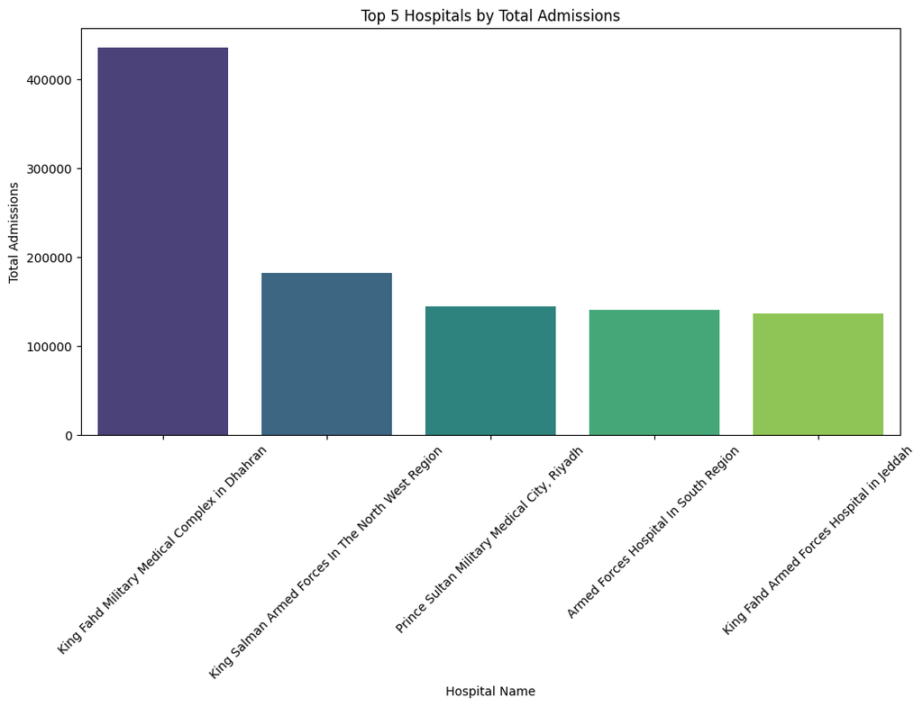

```python
top_n = 5  # Set the number of top hospitals you want to visualize
top_hospitals = df.groupby('hospital_name')['total'].sum().nlargest(top_n)

# Create a new DataFrame with only the top hospitals
top_hospitals_df = df[df['hospital_name'].isin(top_hospitals.index)]

plt.figure(figsize=(12, 6))  # Set the figure size for better visibility

# Use seaborn's barplot to visualize the total admissions for top hospitals
sns.barplot(data=top_hospitals_df, x='hospital_name', y='total', order=top_hospitals.index, palette='viridis')

plt.xlabel('Hospital Name')
plt.ylabel('Total Admissions')
plt.title(f'Top {top_n} Hospitals by Total Admissions')
plt.xticks(rotation=45)  # Rotate x-axis labels for better readability
plt.show()
```

Q2:Are there any noticeable patterns or fluctuations in admissions throughout the year?

```python
months = ['December', 'November', 'October', 'September', 'August', 'July', 'June', 'May', 'April', 'March', 'February', 'January','total']

# Sum the values of each month and add a new row with the totals
df.loc['Total'] = df[months].sum()
```

```python
df.iloc[:, 1:] = df.iloc[:, 1:].astype(int)
```

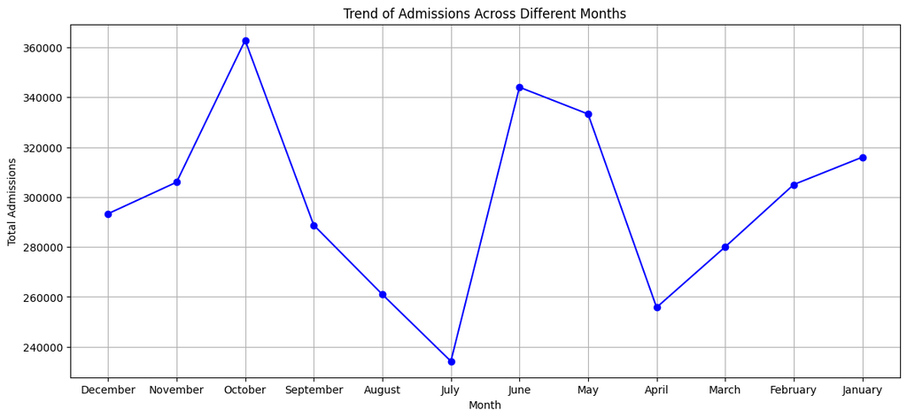

```python
# List of month columns
months = ['December', 'November', 'October', 'September', 'August', 'July', 'June', 'May', 'April', 'March', 'February', 'January']

# Sum the values of each month
total_values = df[months].sum()

# Plotting the trend of admissions across different months
plt.figure(figsize=(14, 6))
plt.plot(months, total_values, marker='o', linestyle='-', color='b')
plt.title('Trend of Admissions Across Different Months')
plt.xlabel('Month')
plt.ylabel('Total Admissions')
plt.grid(True)
plt.show()
```

Q3:Do certain seasons correlate with an increase or decrease in patient admissions?

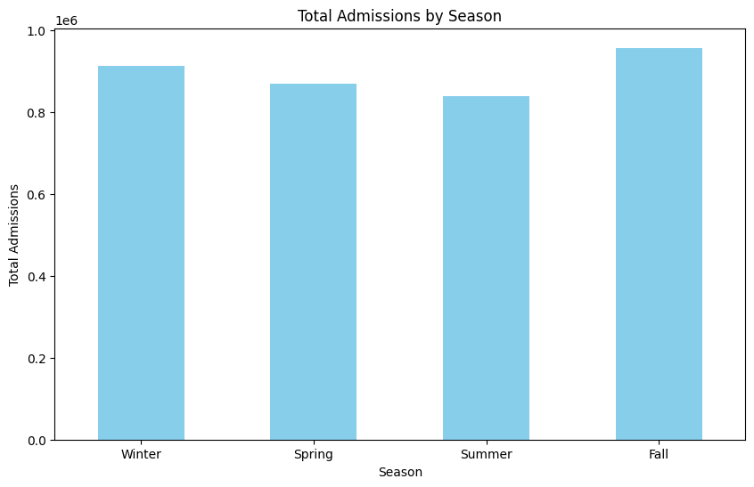

```python
# Create a new DataFrame with seasons as columns
seasons_mapping = {
    'Winter': ['December', 'January', 'February'],
    'Spring': ['March', 'April', 'May'],
    'Summer': ['June', 'July', 'August'],
    'Fall': ['September', 'October', 'November']
}

# Create a new DataFrame with seasons as columns
seasons_df = pd.DataFrame()

# Calculate the total admissions for each season
for season, months in seasons_mapping.items():
    seasons_df[season] = df[months].sum(axis=1)

# Plotting the total admissions for each season
plt.figure(figsize=(10, 6))
seasons_df.sum().plot(kind='bar', color='skyblue')
plt.title('Total Admissions by Season')
plt.xlabel('Season')
plt.ylabel('Total Admissions')
plt.xticks(rotation=0)
plt.show()
```

```python
#Save Final df
df.to_csv('Cleande_Emergency_Data.csv', index=False)
```

# Findings:

### Q1:Which 5 hospitals have the highest total number of admissions?

1-King Fahd Military Medical Complex in Dhahran

2-King Salman Armed Forces In The North West Region

3-Prince Sultan Military Medical City, Riyadh

4-Armed Forces Hospital In South Region

5-King Fahd Armed Forces Hospital in Jeddah

### Q2:Are there any noticeable patterns or fluctuations in admissions throughout the year?

It is evident that the number of admissions is higher in October compared to July, where admissions are at their lowest.

### Q3:Do certain seasons correlate with an increase or decrease in patient admissions?

The fall season experiences a higher volume of admissions, whereas the summer season sees the lowest number of admissions.